# STAT540 - Project 1

Jack Santini

**Note:** If you `Rmd` file submission knits you will receive total of **(5 points)**

### Exploratory Data Analysis Task

Access the data from url http://www.stat.berkeley.edu/users/statlabs/data/babies.data and store the information in an object named BABIES using the function read.table(). A description of the variables can be found at http://www.stat.berkeley.edu/users/statlabs/labs.html. These data are a subset from a much larger study dealing with child health and development.

Access the data on the web from URL http://www.stat.berkeley.edu/users/statlabs/data/babies.data, and store the information in an object named `BABIES` using the function `read.table()`.

**The code chunk 3**: labeled `access` **does that for you**, just review it and run it!

A description of the variables can be found at http://www.stat.berkeley.edu/users/statlabs/labs.html.

These data are a subset from a much larger study dealing with child health and development.

Use the functions `summary()`, `str()` and `dim()` on `BABIES` to find out more about the structure of the data, and report the number of rows and columns of `BABIES`. Review the type of variables.

```r
site <- "http://www.stat.berkeley.edu/users/statlabs/data/babies.data"
BABIES <- read.table(file=url(site), header=TRUE)
b_summary <- summary(BABIES)
b_str <- str(BABIES)
```

```
'data.frame':   1236 obs. of  7 variables:
 $ bwt      : int  120 113 128 123 108 136 138 132 120 143 ...
 $ gestation: int  284 282 279 999 282 286 244 245 289 299 ...
 $ parity   : int  0 0 0 0 0 0 0 0 0 0 ...
 $ age      : int  27 33 28 36 23 25 33 23 25 30 ...
 $ height   : int  62 64 64 69 67 62 62 65 62 66 ...
 $ weight   : int  100 135 115 190 125 93 178 140 125 136 ...
 $ smoke    : int  0 0 1 0 1 0 0 0 0 1 ...
```

```r
b_dim <- dim(BABIES)
b_summary
```

```
      bwt          gestation         parity            age            height          weight
 Min.   : 55.0   Min.   :148.0   Min.   :0.0000   Min.   :15.00   Min.   :53.00   Min.   : 87
 1st Qu.:108.8   1st Qu.:272.0   1st Qu.:0.0000   1st Qu.:23.00   1st Qu.:62.00   1st Qu.:115
 Median :120.0   Median :280.0   Median :0.0000   Median :26.00   Median :64.00   Median :126
 Mean   :119.6   Mean   :286.9   Mean   :0.2549   Mean   :27.37   Mean   :64.67   Mean   :154
 3rd Qu.:131.0   3rd Qu.:288.0   3rd Qu.:1.0000   3rd Qu.:31.00   3rd Qu.:66.00   3rd Qu.:140
 Max.   :176.0   Max.   :999.0   Max.   :1.0000   Max.   :99.00   Max.   :99.00   Max.   :999
     smoke
 Min.   :0.0000
 1st Qu.:0.0000
 Median :0.0000
 Mean   :0.4644
 3rd Qu.:1.0000
 Max.   :9.0000
```

```r
b_str
```

```r
b_dim
```

```
[1] 1236    7
```

> **Your sample comment:** There are 1236 rows and 7 columns in `BABIES`. The variables are: ‘bwt’, ‘gestation’, ‘parity’, ‘age’, ‘height’, ‘weight’, and ‘smoke’, and are they are all of type integer (int).

#### **a-1) (5 points)** Create “clean”" data set that removes subjects if any observations on the subject are “unknown”. The variables `bwt`, `gestation`, `parity`, `age`, `height`, `weight`, and `smoke` use values of 999, 999, 9, 99, 99, 999, and 9, respectively, to denote ‘’unknown.’’ `R` uses `NA` to denote a missing or unavailable value. Re-code the missing values in `BABIES`.

**Hint:** Use something similar to

`BABIES <- BABIES %>% mutate(bwt = ifelse(bwt == 999, NA, bwt))`, check the `ifelse` conditional element selection. The piping with %>% and using the `dplyr` package grammar of data wrangling.

or alternatively you can use the `$` access to elements of data frame

`BABIES$bwt[BABIES$bwt == 999] = NA`. Run the functions `summary()` and `dim()` on your `BABIES` data frame.

#### Solution:

YOUR CODE HERE

```r
## example how to define the NA for bwt variable using the pipe %>% operator and mutate) from dplyr
#BABIES <- BABIES %>% mutate(bwt = ifelse(bwt == 999, NA, bwt))
BABIES <- BABIES %>% mutate(bwt = ifelse(bwt ==999, NA, bwt))
BABIES <- BABIES %>% mutate(gestation = ifelse(gestation ==999, NA, gestation))
BABIES <- BABIES %>% mutate(parity = ifelse(parity ==9, NA, parity))
BABIES <- BABIES %>% mutate(age = ifelse(age ==99, NA, age))
BABIES <- BABIES %>% mutate(height = ifelse(height ==99, NA, height))
BABIES <- BABIES %>% mutate(weight = ifelse(weight ==999, NA, weight))
BABIES <- BABIES %>% mutate(smoke = ifelse(smoke ==9, NA, smoke))

b_summary <- summary(BABIES)
b_dim <- dim(BABIES)
b_summary
```

```
      bwt          gestation         parity            age            height          weight
 Min.   : 55.0   Min.   :148.0   Min.   :0.0000   Min.   :15.00   Min.   :53.00   Min.   : 87.0
 1st Qu.:108.8   1st Qu.:272.0   1st Qu.:0.0000   1st Qu.:23.00   1st Qu.:62.00   1st Qu.:114.8
 Median :120.0   Median :280.0   Median :0.0000   Median :26.00   Median :64.00   Median :125.0
 Mean   :119.6   Mean   :279.3   Mean   :0.2549   Mean   :27.26   Mean   :64.05   Mean   :128.6
 3rd Qu.:131.0   3rd Qu.:288.0   3rd Qu.:1.0000   3rd Qu.:31.00   3rd Qu.:66.00   3rd Qu.:139.0
 Max.   :176.0   Max.   :353.0   Max.   :1.0000   Max.   :45.00   Max.   :72.00   Max.   :250.0
                 NA's   :13                       NA's   :2       NA's   :22      NA's   :36
     smoke
 Min.   :0.0000
 1st Qu.:0.0000
 Median :0.0000
 Mean   :0.3948
 3rd Qu.:1.0000
 Max.   :1.0000
 NA's   :10
```

```r
b_dim
```

```
[1] 1236    7
```

```r
## or alternatively via $ access
#BABIES$bwt[BABIES$bwt == 999] = NA
```

#### **a-2) (5 points)** Use the function `na.omit()`(or the `filter()` function from `dplyr` package) to create a ‘’clean’’ data set that removes subjects if any observations on the subject are ‘’unknown.’’ Store the modified data frame in a data frame named `CLEAN`. Run the function `dim()` on the data frame `CLEAN` to find the number of observations(rows) in the `CLEAN` data.

YOUR CODE HERE:

```r
#1st approach: filter based on a "not a NA" logic to get all non-NAs back., filter(!is.na(variable_name))
#2nd approach: properly reread instructions after 1st approach gave an unchanged 1236x7 DF; now by
#CLEAN = BABIES %>% filter(bwt != 'unknown', gestation != 'unknown', parity != 'unknown', age != 'unknown', weight != 'unknown', height != 'unknown', smoke != 'unknown')
CLEAN = BABIES %>% filter(bwt != 'unknown')
CLEAN = CLEAN %>% filter(gestation != 'unknown')
CLEAN = CLEAN %>% filter(parity != 'unknown')
CLEAN = CLEAN %>% filter(age != 'unknown')
CLEAN = CLEAN %>% filter(weight != 'unknown')
CLEAN = CLEAN %>% filter(height != 'unknown')
CLEAN = CLEAN %>% filter(smoke != 'unknown')

clean_dim = dim(CLEAN)
clean_dim
```

```
[1] 1174    7
```

**Question/Comment:** How many missing values in the data frame `BABIES` are there for `gestation`, `age`, `height`, `weight`, and `smoke`, respectively? How many rows of `BABIES` have no missing values, one missing value, two missing values, and three missing values, respectively? Note: the number of rows in `CLEAN` should agree with your answer for the number of rows in `BABIES` that have no missing values.

```r
## get the number of missing values in columns, uncomment lines below to use
colNAs<- colSums(is.na(BABIES))
colNAs <- as.vector(colSums(is.na(BABIES))) # coerce to a vector

rowNAs <- table(rowSums(is.na(BABIES)))
rowNAs <- as.vector(table(rowSums(is.na(BABIES)))) # coerce to a vector
colNAs
```

```
[1]  0 13  0  2 22 36 10
```

```r
rowNAs
```

```
[1] 1174   43   17    2
```

Comment how this align with the dimensions of your `CLEAN` data.

#### **a-3) (5 points)** Sort the values in `CLEAN` by `bwt`, `gestation`, and `age`. Store the sorted values in a data frame named `byBGA` and show the first/last six rows of `byBGA`.

**Hint:** Use `arrange()` from `dplyr` or `order()` function.

YOUR CODE HERE:

```r
## fill in the ... below to complete the code
byBGA <- CLEAN %>% arrange(bwt, gestation, age)
head(byBGA, 6)
```

|  | bwt | gestation | parity | age | height | weight | smoke |
| --- | --- | --- | --- | --- | --- | --- | --- |
| 1 | 55 | 204 | 0 | 35 | 65 | 140 | 0 |
| 2 | 58 | 245 | 0 | 34 | 64 | 156 | 1 |
| 3 | 62 | 228 | 0 | 24 | 61 | 107 | 0 |
| 4 | 63 | 236 | 1 | 24 | 58 | 99 | 0 |
| 5 | 65 | 232 | 0 | 24 | 66 | 125 | 1 |
| 6 | 65 | 237 | 0 | 31 | 67 | 130 | 0 |

```r
tail(byBGA, 6)
```

|  | bwt | gestation | parity | age | height | weight | smoke |
| --- | --- | --- | --- | --- | --- | --- | --- |
| 1169 | 170 | 303 | 1 | 21 | 64 | 129 | 0 |
| 1170 | 173 | 293 | 0 | 30 | 63 | 110 | 0 |
| 1171 | 174 | 281 | 0 | 37 | 67 | 155 | 0 |
| 1172 | 174 | 284 | 0 | 39 | 65 | 163 | 0 |
| 1173 | 174 | 288 | 0 | 25 | 61 | 182 | 0 |
| 1174 | 176 | 293 | 1 | 19 | 68 | 180 | 0 |

#### **a-4) (5 points)** Using `mutate()` from the `dplyr` package create new variable for the `CLEAN` data `bwt_gr`, the birth weight in grams, using the original variable `bwt` in ounces. Consider `1 ounce = 28.35 grams`.

YOUR CODE HERE:

```r
CLEAN = CLEAN %>%
  mutate(bwt_gr = bwt * 28.35)
CLEAN
```

| bwt | gestation | parity | age | height | weight | smoke | bwt_gr |
| --- | --- | --- | --- | --- | --- | --- | --- |
| 120 | 284 | 0 | 27 | 62 | 100 | 0 | 3402.00 |
| 113 | 282 | 0 | 33 | 64 | 135 | 0 | 3203.55 |
| 128 | 279 | 0 | 28 | 64 | 115 | 1 | 3628.80 |
| 108 | 282 | 0 | 23 | 67 | 125 | 1 | 3061.80 |
| 136 | 286 | 0 | 25 | 62 | 93 | 0 | 3855.60 |
| 138 | 244 | 0 | 33 | 62 | 178 | 0 | 3912.30 |
| 132 | 245 | 0 | 23 | 65 | 140 | 0 | 3742.20 |
| 120 | 289 | 0 | 25 | 62 | 125 | 0 | 3402.00 |
| 143 | 299 | 0 | 30 | 66 | 136 | 1 | 4054.05 |
| 140 | 351 | 0 | 27 | 68 | 120 | 0 | 3969.00 |

[output cut: 990 more lines]

#### **a-5) (5 points)** Let us make your data a bit **unique** for the purpose of the analysis to follow.

We will remove 100 observation at random for each student. Use the code below to do so. It uses the last two digits of your banner ID as value of the random seed, `m`. (my Banner ID ends in `19`, replace `m` with your two digit)

```r
m <- 81 # replace m with last two digits of your banner ID
set.seed(m)
# check ?sample function to see how it works
remove <-sample(1:dim(CLEAN)[1],100) # get at random 50 numbers from 1 to the # of rows in CLEAN data
print("Observation to remove:")
```

```
[1] "Observation to remove:"
```

```r
remove
```

```
  [1]  227  665  652  393  725  933  361  336  655  727  205  441 1004  932 1057  266   94  892  182  343  412
 [22]  138  852  859  409  131  921 1112 1009  443 1007  162  702  558  373  528   34 1153  146  228  270  552
 [43]  543  150  873  603  303  165  534  560  749  886  297  337  962  399  159 1079  910  567  899  721  823
 [64]  514  783  313  351 1166  233  304  112  431  186   37  720  838 1137 1097  474  542  580 1133  810  490
 [85]  456  163 1026  400  847  607 1022  724  102 1094  459 1162 1017    2 1005    5
```

```r
# now using the slice function from the dplyr package get 50 observation removed from the CLEAN data
CLEAN <- slice(CLEAN,-remove)
```

**Good practice:** Save your customized data frame `CLEAN` in your working directory as a `*.csv` file using the function `write.csv()` using the argument `row.names = FALSE`.

```r
write.csv(CLEAN, file="CLEAN.csv", row.names=FALSE)
```

#### **part a-6 (5 points)** Use the `filter()` function to find what percent of the women in `CLEAN` are pregnant with their first child (`parity = 0`) and do not smoke? What about the percent those pregnant not for a first time and smoke.

**Hint:** I have shown below how you do this with `xtabs` and `prop.table`

YOUR CODE HERE!

```r
#CLEAN %>% filter(parity=0, smoke=0)
CLEAN_table <- xtabs(~parity + smoke , data = CLEAN)
prop.table(CLEAN_table)
```

```
      smoke
parity         0         1
     0 0.4450652 0.2905028
     1 0.1629423 0.1014898
```

> **Your answer here:** Approximately 44.5% of women (which is approximately 477 out of 1074 in the CLEAN dataframe) are pregnant with their first child and do not smoke. Approximately 10.1% of women (which is approximately 108 out of 1074 in the CLEAN dataframe) are not pregnant for the first time and do smoke.

#### **part b (10 points)** Use the information in `CLEAN` to create a frequency(or density) histogram of the birth weights of babies whose mothers have never smoked (`smoke = 0`) and another histogram placed directly below the first in the same graphics device for the birth weights of babies whose mothers currently smoke (`smoke = 1`). Make the range of the $x$-axis 800 to 5100 (ounces) for both histograms. Label the $x$-axis “Weight in Grams”. *Extra credit (5 pts), if you create the requested graph with ggplot2).*

YOUR CODE HERE:

[figure not shown]

```r
#bwt_gr is bwt in grams
smoke_plot <- CLEAN %>%
  filter(smoke == 0) %>%
  ggplot(aes(bwt_gr)) +
  xlim(800, 5100) +
  geom_density(fill = "orange") +
  xlab("weight in grams") +
  ggtitle("Birth weight in smoking women")
nosmoke_plot <- CLEAN %>%
  filter(smoke == 1) %>%
  ggplot(aes(bwt_gr)) +
  xlim(800, 5100) +
  geom_density(fill = "blue") +
  xlab("weight in grams") +
  ggtitle("Birth Weight in nonsmoking women")

smoke_plot
```

[figure not shown]

```r
nosmoke_plot
```

#### **part c (5 points)** Based on the histograms, characterize the distribution of baby birth weight for both non-smoking and smoking mothers.

YOUR CODE HERE:

```r
# Using summarise() and group_by() from dplyr
CLEAN_nosmoke <- CLEAN %>% filter(smoke == 1)
CLEAN_smoke <- CLEAN %>% filter(smoke ==0)

CLEAN_nosmoke_grouped <- CLEAN_nosmoke %>% group_by(bwt_gr, smoke)
CLEAN_nosmoke_group_summ <- summarize(CLEAN_nosmoke_grouped)
CLEAN_smoke_grouped <- CLEAN_smoke %>% group_by(bwt_gr, smoke)
CLEAN_smoke_group_summ <- summarize(CLEAN_smoke_grouped)
CLEAN_nosmoke_grouped
```

| bwt | gestation | parity | age | height | weight | smoke | bwt_gr |
| --- | --- | --- | --- | --- | --- | --- | --- |
| 128 | 279 | 0 | 28 | 64 | 115 | 1 | 3628.80 |
| 108 | 282 | 0 | 23 | 67 | 125 | 1 | 3061.80 |
| 143 | 299 | 0 | 30 | 66 | 136 | 1 | 4054.05 |
| 144 | 282 | 0 | 32 | 64 | 124 | 1 | 4082.40 |
| 141 | 279 | 0 | 23 | 63 | 128 | 1 | 3997.35 |
| 110 | 281 | 0 | 36 | 61 | 99 | 1 | 3118.50 |
| 92 | 255 | 0 | 25 | 65 | 125 | 1 | 2608.20 |
| 115 | 261 | 0 | 33 | 60 | 125 | 1 | 3260.25 |
| 119 | 288 | 0 | 43 | 66 | 142 | 1 | 3373.65 |
| 115 | 274 | 0 | 27 | 67 | 175 | 1 | 3260.25 |

[output cut: 411 more lines]

```r
CLEAN_nosmoke_group_summ
```

| bwt_gr | smoke |
| --- | --- |
| 1644.30 | 1 |
| 1842.75 | 1 |
| 1956.15 | 1 |
| 2012.85 | 1 |
| 2041.20 | 1 |
| 2126.25 | 1 |
| 2182.95 | 1 |
| 2211.30 | 1 |
| 2268.00 | 1 |
| 2296.35 | 1 |

[output cut: 73 more lines]

```r
CLEAN_smoke_grouped
```

| bwt | gestation | parity | age | height | weight | smoke | bwt_gr |
| --- | --- | --- | --- | --- | --- | --- | --- |
| 120 | 284 | 0 | 27 | 62 | 100 | 0 | 3402.00 |
| 138 | 244 | 0 | 33 | 62 | 178 | 0 | 3912.30 |
| 132 | 245 | 0 | 23 | 65 | 140 | 0 | 3742.20 |
| 120 | 289 | 0 | 25 | 62 | 125 | 0 | 3402.00 |
| 140 | 351 | 0 | 27 | 68 | 120 | 0 | 3969.00 |
| 114 | 273 | 0 | 30 | 63 | 154 | 0 | 3231.90 |
| 115 | 285 | 0 | 38 | 63 | 130 | 0 | 3260.25 |
| 144 | 261 | 0 | 33 | 68 | 170 | 0 | 4082.40 |
| 105 | 270 | 0 | 22 | 56 | 93 | 0 | 2976.75 |
| 137 | 287 | 0 | 25 | 66 | 145 | 0 | 3883.95 |

[output cut: 643 more lines]

```r
CLEAN_smoke_group_summ
```

| bwt_gr | smoke |
| --- | --- |
| 1559.25 | 0 |
| 1757.70 | 0 |
| 1786.05 | 0 |
| 1842.75 | 0 |
| 2012.85 | 0 |
| 2069.55 | 0 |
| 2126.25 | 0 |
| 2211.30 | 0 |
| 2239.65 | 0 |
| 2268.00 | 0 |

[output cut: 83 more lines]

```r
smoke_mean_weight <- mean(CLEAN_smoke_grouped$bwt_gr)
smoke_sd_weight <- sd(CLEAN_smoke_grouped$bwt_gr)
smoke_var_weight <- var(CLEAN_smoke_grouped$bwt_gr)
smoke_range_weight <- range(CLEAN_smoke_grouped$bwt_gr)

nosmoke_mean_weight <- mean(CLEAN_nosmoke_grouped$bwt_gr)
nosmoke_sd_weight <- sd(CLEAN_nosmoke_grouped$bwt_gr)
nosmoke_var_weight <- var(CLEAN_nosmoke_grouped$bwt_gr)
nosmoke_range_weight <- range(CLEAN_nosmoke_grouped$bwt_gr)

diff_mean_weight <- smoke_mean_weight - nosmoke_mean_weight

print("The mean weights of babies of smokers and nonsmokers, respectively: ")
```

[output not shown]

```r
smoke_mean_weight
```

```
[1] 3492.998
```

```r
nosmoke_mean_weight
```

```
[1] 3223.281
```

```r
print("Mean weight differnce between babies of smokers versus nonsmokers: ")
```

[output not shown]

```r
diff_mean_weight
```

```
[1] 269.7173
```

```r
print("Standard deviations of babies of smokers and nonsmokers, respectively: ")
```

```
[1] "Standard deviations of babies of smokers and nonsmokers, respectively: "
```

```r
smoke_sd_weight
```

```
[1] 489.2536
```

```r
nosmoke_sd_weight
```

```
[1] 516.1856
```

```r
print("Variances of babies of smokers and nonsmokers, respectively: ")
```

```
[1] "Variances of babies of smokers and nonsmokers, respectively: "
```

```r
smoke_var_weight
```

```
[1] 239369.1
```

```r
nosmoke_var_weight
```

```
[1] 266447.6
```

```r
print("Ranges of babies of smokers and nonsmokers, respectively: ")
```

```
[1] "Ranges of babies of smokers and nonsmokers, respectively: "
```

```r
smoke_range_weight
```

```
[1] 1559.25 4989.60
```

```r
nosmoke_range_weight
```

```
[1] 1644.30 4621.05
```

#### **part e (5 points)** Create side-by-side boxplots to compare the birth weights (bwt_gr) of babies whose mother’s never smoked and those who currently smoke. Use `ggplot2` graphs to create the boxplots. Label the $y$-axis “Weight in Grams”.

Hint: Use template like `ggplot(data = ...., aes(...) +` `geom_boxplot()`

YOUR CODE HERE:

[figure not shown]

```r
#nosmoke_box <- ggplot(data = CLEAN_nosmoke, aes(x=bwt_gr)) +
#  geom_boxplot() +
#  ylab("Weight in grams")
#nosmoke_box
boxplot(CLEAN_nosmoke$bwt_gr, CLEAN_smoke$bwt_gr, col='blue', main='Birth Weights', xlab='Nonsmoker v. Smoker', ylab='weight in grams')
```

#### **part f (5 points)** What is the median weight difference between babies who are firstborn (`parity = 0`) and those who are not (`parity = 1`)? Use piping `%>%` and `group_by(` and `summarise()` from `dplyr` package.

YOUR CODE HERE!

```r
CLEAN_first <- CLEAN %>% group_by(parity==0)
CLEAN_notfirst <- CLEAN %>% group_by(parity==1)
CLEAN_first
```

| bwt | gestation | parity | age | height | weight | smoke | bwt_gr | parity == 0 |
| --- | --- | --- | --- | --- | --- | --- | --- | --- |
| 120 | 284 | 0 | 27 | 62 | 100 | 0 | 3402.00 | TRUE |
| 128 | 279 | 0 | 28 | 64 | 115 | 1 | 3628.80 | TRUE |
| 108 | 282 | 0 | 23 | 67 | 125 | 1 | 3061.80 | TRUE |
| 138 | 244 | 0 | 33 | 62 | 178 | 0 | 3912.30 | TRUE |
| 132 | 245 | 0 | 23 | 65 | 140 | 0 | 3742.20 | TRUE |
| 120 | 289 | 0 | 25 | 62 | 125 | 0 | 3402.00 | TRUE |
| 143 | 299 | 0 | 30 | 66 | 136 | 1 | 4054.05 | TRUE |
| 140 | 351 | 0 | 27 | 68 | 120 | 0 | 3969.00 | TRUE |
| 144 | 282 | 0 | 32 | 64 | 124 | 1 | 4082.40 | TRUE |
| 141 | 279 | 0 | 23 | 63 | 128 | 1 | 3997.35 | TRUE |

[output cut: 990 more lines]

```r
summarise(CLEAN_first, median(bwt_gr))
```

| parity == 0 | median(bwt_gr) |
| --- | --- |
| FALSE | 3359.475 |
| TRUE | 3402.000 |

```r
summarise(CLEAN_notfirst, median(bwt_gr))
```

| parity == 1 | median(bwt_gr) |
| --- | --- |
| FALSE | 3402.000 |
| TRUE | 3359.475 |

> **Your answer:** The median weight difference between babies who are firstborn and those who are not is 42.525 grams.

#### **part g (10 points)** Create a single graph of the densities for pre-pregnancy `weight` for mothers who have never smoked and for mothers who currently smoke. Make sure both densities appear in the same graph and have a legend. Label the $x$-axis “Weight in Pounds”. *Use the ggplot2 template for graphics below*

`ggplot(data = ..., aes(x = ..., color = ...)) +` `geom_density(aes(fill = ..., alpha = 0.2)) +` `theme_bw()`

YOUR CODE HERE!

[figure not shown]

```r
#CLEAN_plot <- ggplot(data = CLEAN, aes(x=weight, color='blue')) + geom_density(aes(fill=smoke, alpha=0.2)) + xlab("Weight in Pounds") + theme_bw()

CLEAN_plot <- densityplot(~bwt, data=CLEAN,groups=smoke, main="Weights between smokers and nonsmokers", xlab="Weights in Pounds", auto.key=TRUE)
CLEAN_plot
```

#### **part j (10 points)** Compute the body mass index (`BMI`) for each mother in `CLEAN`. Recall that `BMI` is defined as $\text{kg}/\text{m}^2$ (0.0254 m = 1 in., and 0.45359 kg = 1 lb.). Add the variables weight in kg, height in m, and BMI to `CLEAN` and store the result in `CLEANP`. Show the first six rows of `CLEANP`.

YOUR CODE HERE:

```r
CLEANP <- CLEAN %>% mutate(weight_kg= weight*0.45359, height_m= height*0.0254, BMI= weight_kg * height_m^2)
head(CLEANP, 6)
```

|  | bwt | gestation | parity | age | height | weight | smoke | bwt_gr | weight_kg | height_m | BMI |
| --- | --- | --- | --- | --- | --- | --- | --- | --- | --- | --- | --- |
| 1 | 120 | 284 | 0 | 27 | 62 | 100 | 0 | 3402.0 | 45.35900 | 1.5748 | 112.4901 |
| 2 | 128 | 279 | 0 | 28 | 64 | 115 | 1 | 3628.8 | 52.16285 | 1.6256 | 137.8443 |
| 3 | 108 | 282 | 0 | 23 | 67 | 125 | 1 | 3061.8 | 56.69875 | 1.7018 | 164.2066 |
| 4 | 138 | 244 | 0 | 33 | 62 | 178 | 0 | 3912.3 | 80.73902 | 1.5748 | 200.2324 |
| 5 | 132 | 245 | 0 | 23 | 65 | 140 | 0 | 3742.2 | 63.50260 | 1.6510 | 173.0955 |
| 6 | 120 | 289 | 0 | 25 | 62 | 125 | 0 | 3402.0 | 56.69875 | 1.5748 | 140.6126 |

#### **part k (5 points)** Characterize the distribution of BMI. Create either a histogram or density plot to

help determine the shape of the BMI distribution. Label the $x$-axis “BMI ($kg/m^2$)”.

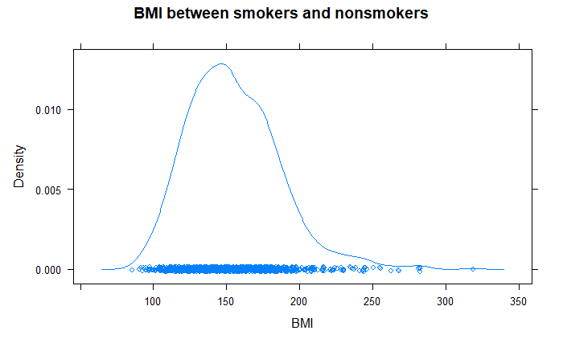

```r
CLEANP_nosmoke <- CLEANP %>% filter(smoke == 1)
CLEANP_smoke <- CLEANP %>% filter(smoke == 0)

#BMI_plot <- ggplot(data=CLEANP, aes(x=BMI))+
#  geom_density(groups = smoke) +xlab("BMI (kg/m^2)")

#BMI_plot <- densityplot(x, data=CLEANP, groups= smoke)
BMI2_plot <- densityplot(~BMI, data=CLEANP, main="BMI between smokers and nonsmokers", xlab="BMI", auto.key=TRUE)
#BMI_plot
BMI2_plot
```

**Your answer:** The shape of the BMI distribution is skewed right.

#### **part l (10 points)** Group pregnant mothers according to their BMI quartile. Find the mean and standard deviation for baby birth weights in each quartile for mothers who have never smoked and those who currently smoke. Find the median and IQR for baby birth weights in each quartile for mothers who have never smoked and those who currently smoke. Based on your answers, would you characterize birth weight in each group as relatively symmetric or skewed? Create histograms and densities of `bwt_gr` conditioned on `BMI` quartiles and whether the mother smokes to verify your previous assertions about the shape.

YOUR CODE HERE:

```r
#quartile function: quantile(x, probs=seq(0, 1, 1/4))
#CLEANP %>% quantile(
preg_quart <- CLEANP %>% group_by(quantile(BMI, probs=seq(0, 1, 14)))
```

#### **Extra credit (10 points)** Create side-by-side boxplots of `bwt_gr` based on whether the mother smokes conditioned on `BMI` quartiles. What do you notice using the boxplots? Which one appears to be bigger factor, smoking or BMI?

YOUR CODE HERE: